# Hidrocodona.

Octubre 2021.

## Generalidades.

## Qué es.

- Un opioide derivado de la codeína.
- Agonista opioide \(\mu\).
- Es el 2.° fármaco de mayor abuso en EE.UU.
  - El preferido entre las mujeres.

[figure not shown]

Ley General de Salud

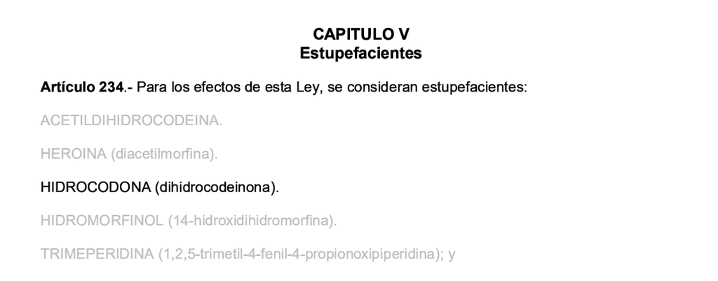

## Propiedades.

- Fórmula: C<sub>18</sub>H<sub>21</sub>NO<sub>3</sub>.
- Peso: 299.4.
- CAS: 125-29-1.

[figure not shown]

## Formas farmacéuticas.

- Cápsula.
- Tableta.

## Indicación.

- Dolor.
  - Agudo y crónico.
  - Moderado y severo.
- Tos y congestión nasal.
  - Resfriado común.
  - Rinitis alérgica.

## Combinaciones.

- Acetaminofén:
  - Dolor crónico.
  - Moderado y severo.
- Ibuprofeno:
  - Dolor agudo.

## Mecanismo de acción.

1. Se une a los receptores opioides:
   - \(\mu\) (MOR).
   - \(\delta\) (DOR).
2. Previene la liberación de neurotransmisores.
3. Suprime la señalización del dolor.
4. Activa la vía de recompensa y adicción.

## LADME.

## Liberación.

- Inmediata (IR).
  - 2.5-10 mg c/ 4-6 h.
- Extendida (ER).
  - 10-20 mg c/ 12-24 h.

## Absorción.

- Cmax en Tmax de:
  - 1 hora (IR).
  - 14-16 horas (ER).

## Distribución.

- Volumen de distribución (Vd):
  - 402 L para un adulto de 70 Kg.

## Metabolismo.

- Metabolitos principales:
  - Hidromorfona (activo).
  - Norhidrocodona (inactivo).

## Excreción.

- Vía renal:
  - Hidrocodona.
  - Metabolitos.

## Efectos secundarios.

## Cardiovasculares.

- Bradicardia.
- Edema periférico.
- Hipertensión.

## Dermatológicos.

- Diaforésis.
- Erupciones cutáneas.
- Prurito.

## Gastrointestinales.

- Dispepsia.
- Dolor abdominal.
- Gastroenteritis.
- Vómito.

## Genitourinarios.

- Infección del tracto urinario.
- Retención urinaria.
  - Hipertrofia prostática.

## Neurológicos.

- Ansiedad.
- Cefalea.
- Escalofrío.
- Fatiga.
- Insomnio.
- Mareo.
- Sedación.
- Somnolencia.

## Óticos.

- Acúfenos.
- Hipoacusia neurosensorial.

## Respiratorios.

- Depresión respiratoria.
- Dificultad respiratoria.
- Infección del tracto respiratorio.

## Contraindicaciones.

## Generales.

- Asma bronquial no tratada.
- Depresión respiratoria significativa.
- Hipersensibilidad.
- Sospecha de obstrucción intestinal.

## Maternidad.

- Embarazo.
  - No contraindicada.
  - Puede causar *síndrome de abstinencia opioide neonatal*.
- Lactancia.
  - Depresión del SNC.
  - Muerte.
  - Somnolencia neonatal.

## Toxicidad.

## Signos.

- Apnea.
- Bradicardia.
- Cianosis.
- Dificultad respiratoria severa.
- Hipotensión arterial.
- Miosis.
- Pérdida de consciencia.

[figure not shown]

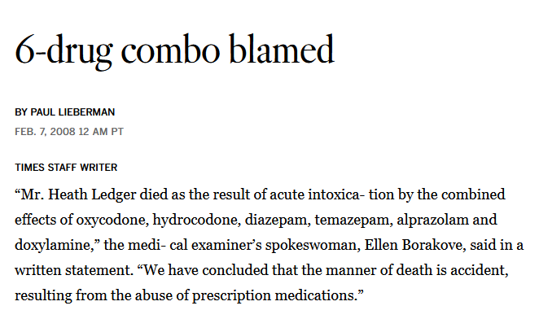

## Bibliografía.

1. Alsanosi et al. (2014). Chapter 17 - Pharmacokinetic Pharmacogenomics. In S. Padmanabhan (Ed.), *Handbook of pharmacogenomics and stratified medicine* (pp. 341–364). Academic Press. https://doi.org/10.1016/B978-0-12-386882-4.00017-7

2. Cardia et al. (2018). Preclinical and clinical pharmacology of hydrocodone for chronic pain: A mini review. *Frontiers in Pharmacology*, *9:1122*. https://doi.org/10.3389/fphar.2018.01122

3. Cofano, S. and Yellon, R. (2021). Hydrocodone. *StatPearls [Internet]*. https://www.ncbi.nlm.nih.gov/books/NBK537288/

4. DrugBank Online. (2021). *Hydrocodone: Uses, interactions, mechanism of action*. https://go.drugbank.com/drugs/DB00956

5. Lieberman, P. (2008). 6-drug combo blamed. *Los Angeles Times*. https://www.latimes.com/archives/la-xpm-2008-feb-07-et-ledger7-story.html

6. Liu et al. (2019). Effects of rescheduling hydrocodone on opioid prescribing in Ohio. *Pain Medicine*, *21*(9), 1863–1870. https://doi.org/10.1093/pm/pnz210

7. National Center for Biotechnology Information. (2021). *PubChem compound summary for CID 5284569, hydrocodone*. https://pubchem.ncbi.nlm.nih.gov/compound/Hydrocodone